# Tutorial - Workshop R - BIOME

#### Análises funcionais

##### Agora que vimos os dados taxonômicos, suas diferenças e quem são os grupos presentes, vamos analisar as funções que eles desempenham nos ambientes

Primeiro, vamos carregar os dados. Nós recebemos os dados diretamente do superfocus, uma matriz em percentual, com todas os níveis e funções, com tabulação como separador de células, e as amostras como colunas.

```r
all_lvl <- read.csv("inputs/all_levels_and_functions_groundwater.csv", sep = "\t")
```

Como podem observar, nossa tabela e um pouco pesada. Então, não recomendo abrir com o “view” ou que abram ela inteira no console. A não ser que confiem bastante na sua máquina.

Vamos tentar visualizar para termos uma noção de como ela é

```r
all_lvl[1:10,1:6]
```

```
##                                   Subsystem.Level.1
## 1  Cofactors, Vitamins, Prosthetic Groups, Pigments
## 2                           Motility and Chemotaxis
## 3              Fatty Acids, Lipids, and Isoprenoids
## 4  Cofactors, Vitamins, Prosthetic Groups, Pigments
## 5              Fatty Acids, Lipids, and Isoprenoids
## 6                       Amino Acids and Derivatives
## 7                  Metabolism of Aromatic Compounds
## 8                       Amino Acids and Derivatives
## 9                             Phosphorus Metabolism
## 10                                    Miscellaneous
##                                                    Subsystem.Level.2
## 1                                               Riboflavin, FMN, FAD
## 2              Social motility and nonflagellar swimming in bacteria
## 3                                                        Fatty acids
```

[output cut: 40 more lines]

Acho que encontramos problemas nessa breve visualização. Temos colunas com valores “-” e colunas com NA. Posso adiantar a vocês que esses “hífens” aparecem quando a função só possui níveis 1, 3 e 4. E isso acontece em mais de uma função. Ou seja, temos um “nome” igual para funções diferentes. Outro problema, são os NA’s, que aparecem quando aquela coluna não tem um valor para aquela função naquela amostra.

Vamos resolver uma coisa por vez. Primeiro os hífens. Vamos usar as funções que já usamos antes, junto com algumas condicionais. Aqui, usamos a função mutate para criar uma nova coluna, parecida com a coluna “Subsystem Level 2”, mas onde os hífens serão trocados pelo valor da célula de “Subsystem Level 1”. Assim, essa linha vai ter uma informação sobre ela, e que não vai ser confundida.

```r
all_lvl <- all_lvl %>%
  mutate(
    subsystem_level2_new =
      case_when(
        all_lvl[,2] == "-" ~ Subsystem.Level.1,
        TRUE ~ Subsystem.Level.2
      )
  )
```

Vamos trazer essa coluna nova para o começo, e então comparamos para ver se deu certo. Para isso, vamos usar a função *relocate*:

```r
all_lvl <- all_lvl %>% relocate(subsystem_level2_new, .before = Subsystem.Level.3)
all_lvl[1:15,1:4]
```

```
##                                   Subsystem.Level.1
## 1  Cofactors, Vitamins, Prosthetic Groups, Pigments
## 2                           Motility and Chemotaxis
## 3              Fatty Acids, Lipids, and Isoprenoids
## 4  Cofactors, Vitamins, Prosthetic Groups, Pigments
## 5              Fatty Acids, Lipids, and Isoprenoids
## 6                       Amino Acids and Derivatives
## 7                  Metabolism of Aromatic Compounds
## 8                       Amino Acids and Derivatives
## 9                             Phosphorus Metabolism
## 10                                    Miscellaneous
## 11                    Regulation and Cell signaling
## 12                                      Respiration
## 13                                    Carbohydrates
## 14 Cofactors, Vitamins, Prosthetic Groups, Pigments
```

[output cut: 49 more lines]

Deu certo! Agora não temos valores iguais pra funções de níveis diferentes. Vamos remover a coluna antiga

```r
all_lvl <- all_lvl[,-2]
```

Vamos agora remover as primeiras colunas, deixando apenas as informações do nível 4 das funções. Depois, vamos transpor a tabela

```r
transp <- all_lvl[,-c(1:3)]
transp <- as.data.frame(t(transp))
```

Vamos agora trazer o nome das amostras para o dataframe, transformando em coluna com a função *rownames_to_column*

```r
transp <- rownames_to_column(transp, var = "Samples")
```

Vamos agora filtrar essas amostras, para termos certeza que só iremos analisar amostras de aquíferos. Primeiro, vamos criar vetores com as amostras da tabela bruta

```r
samples_to_filter <- transp[-1,1]
```

E agora, aplicamos o filtro com a condicional “%in%”, do **dplyr**. Nela, só incluímos em filtered as colunas de “transp” que estão em “samples”

```r
#Usamos o vetor "samples" que havíamos criado antes, com a tabela taxonômica. Assim temos certeza de só analisar as mesmas amostras
filtered <-transp[samples_to_filter %in% samples,]
```

Agora, vamos resolver o nosso segundo problema, os “NA’s” nas colunas. Para isso, o R apresenta uma função que identifica as células com o valor “NA”, então podemos preenchê-las com o que quisermos. Vamos usar 0. Afinal, elas não tem abundância naquela amostra.

```r
filtered[is.na(filtered)] <- 0
```

Vamos colocar as funções como o nome das colunas, com:

```r
colnames(filtered) <- c(filtered[1,])
#Então removemos essa linha
filtered <- filtered[-1,]
```

Vamos unir com as informações das categorias

```r
level4 <- cbind(category, filtered)
```

Enfim temos nossos dados organizados e sem nenhum NA. Mas ainda falta uma coisa. Para padronizar, precisamos que nossos dados estejam em abundância relativa.

Primeiro, vamos nos certificar de que depois de todos esses processos, nossos dados ainda são interpretados pelo R como numéricos. Usamos a função *apply* para aplicar uma mesma função várias vezes num dataframe

```r
level4_relative <- apply(level4[3:ncol(level4)], 2, as.numeric)
```

Depois disso, precisamos converter os dados de abundância percentual para abundância relativa. Para isso, basta dividir todos os valores por 100

```r
level4_relative <- (level4_relative)/100
```

```r
apply(level4_relative, 1, sum)
```

```
##   [1] 1 1 1 1 1 1 1 1 1 1 1 1 1 1 1 1 1 1 1 1 1 1 1 1 1 1 1 1 1 1 1 1 1 1 1 1 1
##  [38] 1 1 1 1 1 1 1 1 1 1 1 1 1 1 1 1 1 1 1 1 1 1 1 1 1 1 1 1 1 1 1 1 1 1 1 1 1
##  [75] 1 1 1 1 1 1 1 1 1 1 1 1 1 1 1 1 1 1 1 1 1 1 1 1 1 1 1 1 1 1 1 1 1 1 1 1 1
## [112] 1 1 1 1
```

Vamos unir os dados novamente

```r
level4_relative <- cbind(level4[1:3], level4_relative)
```

E agora sim, definitivamente, temos uma tabela no mesmo padrão que a anterior, sem erros que possam prejudicar as análises!

Vamos salvar com:

```r
write.table(level4, file = paste("inputs/functional_geral_matrix_lvl4_",d,".csv"), sep = ",", row.names = F)
write.table(level4, file = paste("inputs/functional_geral_matrix_lvl4_",d,".xls"), sep = "\t", row.names = F)
```

Lembrando sempre de usar a função *paste* que literalmente cola no lugar tudo que você digitar.

##### Mas aqui nós temos todas as funções no nível 4. E se quisermos ser menos específicos? Ou quisermos avaliar as funções nos níveis mais gerais? Vamos então gerar as outras tabelas em outros níveis taxonômicos.

Para que a gente não dependa do script que gera a matriz nível 4, o ideal é fazer um script independente dele. Por isso, não vamos aproveitar os objetos já criados e “resolvidos” da tabela anterior. Vamos começar tudo do zero. A parte boa é que já sabemos as funções e os passos a seguir. Seremos breves aqui.

Daquela tabela inicial, enviada pelo coleguinha, vamos pegar apenas as informações das funções no nível 3, e criar um dataframe só com os valores numéricos

```r
level3 <- all_lvl[,-c(4)]
level3_num <- level3[,-c(1:3)]
```

Vamos também converter os nomes das funções em nível 3 em fatores

```r
level3$Subsystem.Level.3 <- as.factor(level3$Subsystem.Level.3)
```

Vamos também converter os valores das células para números, substituir os NA’s por 0 e também dividir tudo por 100, deixando os dados em abundância relativa (O a 1).

```r
level3_num <- as.data.frame(apply(level3_num[1:ncol(level3_num)], 2, as.numeric))
level3_num[is.na(level3_num)] <- 0
level3_num <- level3_num/100
```

Podemos ver que temos um problema, não é? Temos várias funções em nível 4 para uma mesma função em nível 3. Ou seja, as funções em nível 3 aparecem várias vezes ao longo da tabela. Precisamos consolidar tudo isso em uma informação só. Podemos simplificar, e somar todos os valores das funções de nível 4 que pertencem a determinado nível 3. Exemplo: Metabolismo de nitrogênio é uma função geral. Assimilação de nitrogênio, dissimilação de nitrogênio, annamox, são funções específicas. Se somarmos os valores dessas 3 funções específicas, teremos a abundância total do metabolismo de nitrogênio naquele metagenoma.

Agora vamos executar uma linha que vai combinar todos os valores das células com base nas funções em nível 3. Aqui, vamos usar o *group_by*, que vai receber um vetor que se repete (Level 3) e então executar a função que a gente quer usar para agrupar os valores designados.

```r
level3_sum <- level3_num %>%
  group_by(level3$Subsystem.Level.3) %>%
  summarise_all(funs(sum))
```

Pronto. Agora nós temos todos aqueles dados sumarizados pelas funções no nível 3. Assim como antes, também vamos filtrar e remover as amostras que de acordo com os metadados não são aquíferos.

```r
transp <- t(level3_sum)
transp <- as.data.frame(transp)
transp <- rownames_to_column(transp, var = "Samples")

transp <- transp[samples_to_filter %in% samples,]
```

Vamos agora ajustar as informações da tabela, colocando as funções como nome das colunas e combinando os dados com as categorias. Além disso, vamos nos certificar que depois de tudo isso, nossos dados ainda são numéricos.

```r
colnames(transp) <- c(transp[1,])
transp <- transp[-1,]

level3_relative <- cbind(category, transp)

level3_relative[,3:ncol(level3_relative)] <- as.data.frame(apply(level3_relative[3:ncol(level3_relative)], 2, as.numeric))
```

Vamos checar e conferir se os dados estão corretos

```r
rowSums(level3_relative[,3:ncol(level3_relative)])
```

```
##   2   3   4   5   6   7   8   9  10  11  12  13  14  15  16  17  18  19  20  21
##   1   1   1   1   1   1   1   1   1   1   1   1   1   1   1   1   1   1   1   1
##  22  23  24  25  26  27  28  29  30  31  32  33  34  35  36  37  38  39  40  41
##   1   1   1   1   1   1   1   1   1   1   1   1   1   1   1   1   1   1   1   1
##  42  43  44  45  46  47  48  49  50  51  52  53  54  55  56  57  58  59  60  61
##   1   1   1   1   1   1   1   1   1   1   1   1   1   1   1   1   1   1   1   1
##  62  63  64  65  66  68  69  70  71  72  73  74  75  76  77  78  79  80  81  82
##   1   1   1   1   1   1   1   1   1   1   1   1   1   1   1   1   1   1   1   1
##  83  84  85  86  87  88  89  90  91  92  93  94  95  96  97  98  99 100 147 149
##   1   1   1   1   1   1   1   1   1   1   1   1   1   1   1   1   1   1   1   1
## 150 151 152 153 154 155 156 157 158 159 160 161 162 163 164
##   1   1   1   1   1   1   1   1   1   1   1   1   1   1   1
```

Agora podemos salvar as nossas novas matrizes. Lembrando de usar a nossa data, pra organizar os dados.

```r
write.table(level3_relative, file = paste("inputs/functional_geral_matrix_lvl3_",d,".csv", sep = ""), sep = ",", row.names = F)
write.table(level3_relative, file = paste("inputs/functional_geral_matrix_lvl3_",d,".xls", sep = ""), sep = "\t", row.names = F)
```

Usando a mesma lógica, vocês podem repetir para nível 2 e nível 1 também. Assim, vão obter matrizes com os 4 diferentes níveis funcionais, e podem analisar o que mais for adequado para o seu trabalho.

Pra simplificar esse tutorial, vamos ficar com o nível 3 mesmo. Mas eu você pode (e eu recomendo) que você tente repetir isso pros outros níveis também. Mas só se você quiser.

Agora que temos a matriz, que tal reproduzir algumas das análises que já conhecemos para as funções?

Vamos carregar a matriz primeiro. Mudem a data da tabela para a data do dia que salvaram a matriz.

```r
data <- read.csv("inputs/functional_geral_matrix_lvl3_2021_09_27.csv")
data[1:5,1:5]
```

```
##              category level3.Subsystem.Level.3 X.GlcNAc.2.Catabolic.Operon
## 1 Porous Contaminated                DRR125227                1.457064e-06
## 2 Porous Contaminated                DRR125228                0.000000e+00
## 3 Porous Contaminated                DRR125229                2.103542e-07
## 4 Porous Contaminated                DRR125230                1.337990e-05
## 5 Porous Contaminated                DRR125231                6.644280e-05
##   X..945..Fimbriae X..945..related.Fimbriae.in.Yersinia
## 1     0.000000e+00                                    0
## 2     2.222104e-07                                    0
## 3     0.000000e+00                                    0
## 4     0.000000e+00                                    0
## 5     0.000000e+00                                    0
```

Dá pra ver que a segunda coluna está com um nome bem confuso né? Não mudamos na hora de salvar. Falta de atenção <sub>sua</sub> nossa. Vamos mudar agora. Vamos também criar um dataframe apenas com os dados numéricos

```r
colnames(data)[2] <- "Samples"
data_num <- select_if(data, is.numeric)
```

Ah, vamos nos antecipar também, e criar um anosim, para também analisar estatisticamente os nossos dados.

```r
danosim <- anosim(data_num,category)
```

Agora sim, podemos ir ao plot. Aqui, vamos copiar o mesmo código que usamos para aquele primeiro nMDS. Vamos só mudar o título do plot, claro, e o nome do objeto em que salvamos ele.

[figure not shown]

```r
plot_fun <- ggplot(ord_df, aes(x=MDS1, y=MDS2, color=Category)) +
  geom_point(size = 4) +
  theme_bw()+
  labs(title = "Function Level 3")+
  theme(plot.title = element_text(face = "bold", size = 18))+
  theme(legend.position = "right", legend.title = element_text(size = 18, face = "bold"))+
  theme(panel.border = element_rect(colour = "black", size=1))+
  theme(legend.key=element_rect(fill='white'))+
  theme(legend.key = element_rect(colour = "white"))+
  scale_colour_manual(values=c("#43CD80","#9400D3","#c2c212", "#3eb5bf", "#7e3c03", "#0f0476"))+
  theme(legend.text=element_text(size=18))+
  theme(axis.title.x = element_text(face="bold", size=18))+
  theme(axis.title.y = element_text(face="bold", size=18))+
  theme(axis.text.x = element_text(size=18,color="black"))+
  theme(axis.text.y = element_text(size=18,color="black"))+
  theme(axis.line.x=element_blank())+
  theme(axis.line.y=element_blank())+
  annotate("text", x = 0.4, y = 1.2, label = paste("Stress=",round(ord$stress, digits=3)), size = 4)+
  annotate("text", x=0.4, y=1, label = paste("R²=",round(danosim$statistic, digits = 3)), size = 4)+
  annotate("text", x=0.4, y=0.8, label = paste("pvalue=",round(danosim$signif, digits = 4)), size = 4)+
  theme(panel.grid.major.x = element_blank() ,
        panel.grid.minor.x = element_blank() ,
        panel.grid.major.y = element_blank(),
        panel.grid.minor.y = element_blank())

plot_fun
```

Vamos salvar o nosso plot

```r
ggsave(plot = plot_fun, file=paste("outputs/output_nMDS_funcional_lvl3_modified_",d,".jpg", sep = ""), width=10, height=10)
ggsave(plot = plot_fun, file=paste("outputs/output_nMDS_funcional_lvl3_modified_",d,".svg", sep = ""), width=10, height=10)
ggsave(plot = plot_fun, file=paste("outputs/output_nMDS_funcional_lvl3_modified_",d,".png", sep = ""), width=10, height = 10)
```

#### Unindo plots

Mas e se a gente quiser juntar os dois plots em uma figura só? Existem vários softwares de manipulação de imagens em vetores (png ou svg). Mas é interessante que façamos isso no R também. Pode simplificar o trabalho, principalmente em casos de figuras muito grandes, que demoram muito ou são impossíveis de abrir em um desses programas.

Primeiro, vamos usar um pacote que ajuda muito na manipulação de plots produzidos no R, o **cowplot**

```r
library(cowplot)
```

Vamos criar um objeto somente com as legendas do plot 2

```r
legend_nmds <- get_legend(plot_tax)
```

Agora, vamos remover as legendas dos dois plots

```r
plot_tax <- plot_tax + theme(legend.position = "none")

plot_fun <- plot_fun + theme(legend.position = "none")
```

Agora, vamos usar a função *plot_grid* para plotar os três elementos (duas figuras + legendas) de forma independente

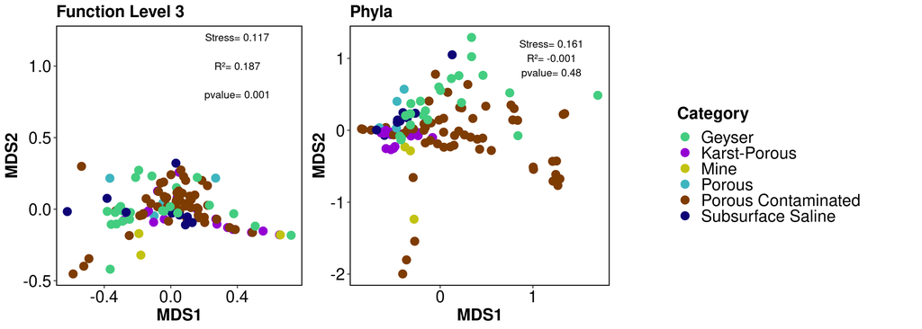

```r
plot_grid(plot_fun, plot_tax, legend_nmds, align = "h", ncol = 3, greedy = T)
```

Salvem o novo gráfico

```r
ggsave(file=paste("outputs/new_nmds_groundwater_panel",d,".jpg"), width=30, height=10)
ggsave(file=paste("outputs/new_nmds_groundwater_panel",d,".svg"), width=30, height=10)
ggsave(file=paste("outputs/new_nmds_groundwater_panel",d,".png"), width=30, height=10)
```

#### Produzindo mapas

##### Já temos uma análise dos nossos dados, já podemos ver a composição das comunidades microbianas e suas diferenças em relação aos seus ambientes. Mas a grande pergunta é: Onde ficam todas essas coisas?

Para nossa sorte, tempos os dados de localização de todas essas amostras. Vamos agora aprender a como visualizar isso em um mapa?

Primeiro, vamos carregar os dados de input

```r
metadata <- read.csv("inputs/annotated_groundwater_samples_metadata_2021-02-16.csv")
```

O próprio ggplot já te dá uma função para produzir mapas, a *map_data*

```r
world <- map_data("world")
```

Você pode escolher qual mapa quiser, basta colocar o país ou região que quiser. Claro que isso só se aplica em caso de seus dados serem exclusivos de uma região. Como esses dados são globais, vamos ficar com o mapa clássico mesmo.

Vamos adicionar a informação de quantas amostras existem em cada tipo de aquífero. Criamos um dataframe com as frequências dessas categorias

```r
ntypes <- as.data.frame(table(metadata$level_3))
```

Vamos ao nosso plot. Ele funciona de forma muito parecida com os outros. Aqui, o ggplot vai receber a função *geom_map* para reconhecer os objetos de mapa que criamos, e as latitudes e longitudes dos nossos dados.

Nossa informação sobre o número de amostras em cada tipo de aquífero vai ser adicionado com a legenda de cores, e assim, na função *scale_color_manual* nós usamos a função *paste* para colar as informações que colocamos no dataframe com essas frequências.

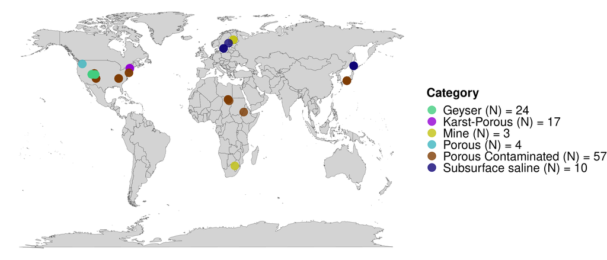

```r
world_map <- ggplot() +
  geom_map(data = world, map = world, aes(long, lat, map_id = region), color = "black", fill = "lightgray", size = 0.1)+
  geom_point(data = metadata, aes(longitude, latitude, color = level_3), alpha = 0.8, size = 6)+
  theme_void() +
  scale_color_manual(labels = c(paste(ntypes[1,1], "(N) =", ntypes[1,2]), paste(ntypes[2,1], "(N) =", ntypes[2,2]),
                                paste(ntypes[3,1], "(N) =", ntypes[3,2]), paste(ntypes[4,1], "(N) =", ntypes[4,2]),
                                paste(ntypes[5,1], "(N) =", ntypes[5,2]), paste(ntypes[6,1], "(N) =", ntypes[6,2])),
                                values=c("#43CD80","#9400D3","#c2c212", "#3eb5bf",
                                         "#7e3c03", "#0f0476"))+
  theme(legend.title = element_text(face = "bold", size = 20))+
  theme(legend.text = element_text(size = 20))+
  theme(plot.title = element_text(face = "bold", size = 20))+
  labs(color = "Category")

world_map
```

Podemos agora salvar o nosso mapa

```r
ggsave(world_map, file = paste("outputs/Groundwater_distribution_map_",d,".svg", sep = ""), width = 16, height = 10, dpi = 500)
ggsave(world_map, file = paste("outputs/Groundwater_distribution_map_",d,".png", sep = ""), width = 16, height = 10, dpi = 500)
```

E voilà, temos agora os pontos onde cada amostra foi coletada!

Bom, isso é tu-tu-tudo pessoal!

Espero que vocês tenham gostado da experiência, espero que consigam utilizar as coisas passadas aqui, e espero que peguem o gosto pelo R!

Esse documento foi feito com uma outra ferramenta um pouco mais avançada dentro do próprio Rstudio, que integra o script em R com markdown.

O potencial da ferramenta é enorme! Espero que aproveitem bastante tudo que ela pode oferecer!

A minha intenção é que esse documento seja disponibilizado para as próximas pessoas que entrarem no lab, servindo também como um guia inicial/tutorial para o R. Portanto, qualquer dúvida ou sugestão, podem entrar em contato!